# INN_Learner_Notebook_Full_code_version_FINAL_Amardeep_v05

### Neural Network with Adam Optimizer and Dropout

```python
# Clear the session and fix the random number seed
tf.keras.backend.clear_session()
np.random.seed(42)
random.seed(42)
tf.random.set_seed(42)

# Setup the NN archicature - We will add the drop out architecture here along with a few addtional layers
model_2 = Sequential()
model_2.add(Dense(128, activation='relu', input_dim = X_train.shape[1]))  # First hidden layer with 128 neurons and relu activation function
model_2.add(Dropout(0.5))                                     # Switching 20% of neurons off randomly at each iteration to avoid overfitting
model_2.add(Dense(64, activation='relu'))                     # Second hidden layer with 64 neurons and relu activation function
model_2.add(Dropout(0.5))                                     # Switching 20% of neurons off randomly at each iteration to avoid overfitting
model_2.add(Dense(32, activation='relu'))                     # Third hidden layer with 32 neurons and relu activation function
model_2.add(Dense(1, activation='sigmoid'))                   # Output layer

# Define the optimization parameters and compile the model
optimizer_adam = tf.keras.optimizers.Adam(learning_rate=0.0005)
metric_R = keras.metrics.Recall()
loss_fuc = 'binary_crossentropy'
model_2.compile(loss = loss_fuc, optimizer = optimizer_adam, metrics=metric_R)
model_2.summary()
```

```
Model: "sequential"
_________________________________________________________________
 Layer (type)                Output Shape              Param #
=================================================================
 dense (Dense)               (None, 128)               1536

 dropout (Dropout)           (None, 128)               0

 dense_1 (Dense)             (None, 64)                8256

 dropout_1 (Dropout)         (None, 64)                0

 dense_2 (Dense)             (None, 32)                2080

 dense_3 (Dense)             (None, 1)                 33

=================================================================
Total params: 11905 (46.50 KB)
Trainable params: 11905 (46.50 KB)
Non-trainable params: 0 (0.00 Byte)
_________________________________________________________________
```

```python
#Fit the neural network on the train and validation sets
#retain the same batch size and epochs as earlier
batch_size = 32
epochs = 100

start = time.time()
history_2 = model_2.fit(X_train, y_train, validation_data=(X_val,y_val) , batch_size=batch_size, epochs=epochs, verbose=2)
end = time.time()
```

```
178/178 - 2s - loss: 0.5305 - recall: 0.0783 - val_loss: 0.4566 - val_recall: 0.0000e+00 - 2s/epoch - 13ms/step
178/178 - 1s - loss: 0.4686 - recall: 0.0112 - val_loss: 0.4384 - val_recall: 0.0103 - 560ms/epoch - 3ms/step
178/178 - 1s - loss: 0.4541 - recall: 0.0645 - val_loss: 0.4288 - val_recall: 0.0646 - 565ms/epoch - 3ms/step
178/178 - 1s - loss: 0.4454 - recall: 0.1015 - val_loss: 0.4245 - val_recall: 0.1757 - 584ms/epoch - 3ms/step
178/178 - 1s - loss: 0.4397 - recall: 0.1463 - val_loss: 0.4203 - val_recall: 0.2274 - 504ms/epoch - 3ms/step
178/178 - 1s - loss: 0.4378 - recall: 0.1764 - val_loss: 0.4162 - val_recall: 0.2248 - 535ms/epoch - 3ms/step
178/178 - 1s - loss: 0.4320 - recall: 0.1962 - val_loss: 0.4133 - val_recall: 0.2481 - 570ms/epoch - 3ms/step
178/178 - 1s - loss: 0.4301 - recall: 0.2151 - val_loss: 0.4146 - val_recall: 0.3049 - 614ms/epoch - 3ms/step
178/178 - 1s - loss: 0.4218 - recall: 0.2547 - val_loss: 0.4095 - val_recall: 0.3101 - 534ms/epoch - 3ms/step
178/178 - 1s - loss: 0.4247 - recall: 0.2599 - val_loss: 0.4108 - val_recall: 0.3178 - 579ms/epoch - 3ms/step
178/178 - 1s - loss: 0.4168 - recall: 0.2719 - val_loss: 0.4068 - val_recall: 0.3566 - 601ms/epoch - 3ms/step
178/178 - 0s - loss: 0.4155 - recall: 0.2840 - val_loss: 0.4080 - val_recall: 0.3437 - 499ms/epoch - 3ms/step
178/178 - 1s - loss: 0.4130 - recall: 0.2831 - val_loss: 0.4073 - val_recall: 0.3152 - 1s/epoch - 7ms/step
178/178 - 1s - loss: 0.4127 - recall: 0.2806 - val_loss: 0.4041 - val_recall: 0.3359 - 705ms/epoch - 4ms/step
178/178 - 1s - loss: 0.4017 - recall: 0.3090 - val_loss: 0.3982 - val_recall: 0.3230 - 567ms/epoch - 3ms/step
178/178 - 1s - loss: 0.4086 - recall: 0.3038 - val_loss: 0.3984 - val_recall: 0.3282 - 974ms/epoch - 5ms/step
178/178 - 1s - loss: 0.4053 - recall: 0.3072 - val_loss: 0.4002 - val_recall: 0.3488 - 825ms/epoch - 5ms/step
178/178 - 1s - loss: 0.4014 - recall: 0.3201 - val_loss: 0.3927 - val_recall: 0.3385 - 1s/epoch - 6ms/step
178/178 - 1s - loss: 0.3983 - recall: 0.3210 - val_loss: 0.3936 - val_recall: 0.3592 - 859ms/epoch - 5ms/step
178/178 - 1s - loss: 0.3978 - recall: 0.3382 - val_loss: 0.3903 - val_recall: 0.3592 - 514ms/epoch - 3ms/step
178/178 - 1s - loss: 0.3952 - recall: 0.3451 - val_loss: 0.3889 - val_recall: 0.3592 - 536ms/epoch - 3ms/step
178/178 - 1s - loss: 0.3978 - recall: 0.3348 - val_loss: 0.3905 - val_recall: 0.3902 - 509ms/epoch - 3ms/step
178/178 - 1s - loss: 0.3902 - recall: 0.3511 - val_loss: 0.3849 - val_recall: 0.3721 - 588ms/epoch - 3ms/step
178/178 - 1s - loss: 0.3837 - recall: 0.3752 - val_loss: 0.3895 - val_recall: 0.4109 - 598ms/epoch - 3ms/step
178/178 - 1s - loss: 0.3921 - recall: 0.3657 - val_loss: 0.3830 - val_recall: 0.3824 - 627ms/epoch - 4ms/step
178/178 - 1s - loss: 0.3847 - recall: 0.3546 - val_loss: 0.3840 - val_recall: 0.3979 - 561ms/epoch - 3ms/step
178/178 - 1s - loss: 0.3860 - recall: 0.3933 - val_loss: 0.3815 - val_recall: 0.3747 - 545ms/epoch - 3ms/step
178/178 - 1s - loss: 0.3853 - recall: 0.3657 - val_loss: 0.3801 - val_recall: 0.4005 - 591ms/epoch - 3ms/step
178/178 - 0s - loss: 0.3836 - recall: 0.3769 - val_loss: 0.3799 - val_recall: 0.4315 - 490ms/epoch - 3ms/step
178/178 - 1s - loss: 0.3778 - recall: 0.4036 - val_loss: 0.3771 - val_recall: 0.4031 - 550ms/epoch - 3ms/step
178/178 - 1s - loss: 0.3780 - recall: 0.3838 - val_loss: 0.3757 - val_recall: 0.4315 - 564ms/epoch - 3ms/step
178/178 - 1s - loss: 0.3792 - recall: 0.4062 - val_loss: 0.3728 - val_recall: 0.4134 - 505ms/epoch - 3ms/step
178/178 - 1s - loss: 0.3736 - recall: 0.4157 - val_loss: 0.3717 - val_recall: 0.4315 - 560ms/epoch - 3ms/step
178/178 - 0s - loss: 0.3730 - recall: 0.4079 - val_loss: 0.3729 - val_recall: 0.4470 - 499ms/epoch - 3ms/step
178/178 - 1s - loss: 0.3713 - recall: 0.4105 - val_loss: 0.3703 - val_recall: 0.4419 - 619ms/epoch - 3ms/step
178/178 - 1s - loss: 0.3670 - recall: 0.4122 - val_loss: 0.3677 - val_recall: 0.4315 - 556ms/epoch - 3ms/step
178/178 - 1s - loss: 0.3619 - recall: 0.4191 - val_loss: 0.3685 - val_recall: 0.4393 - 630ms/epoch - 4ms/step
178/178 - 1s - loss: 0.3600 - recall: 0.4200 - val_loss: 0.3670 - val_recall: 0.4393 - 795ms/epoch - 4ms/step
178/178 - 1s - loss: 0.3599 - recall: 0.4389 - val_loss: 0.3655 - val_recall: 0.4625 - 802ms/epoch - 5ms/step
178/178 - 1s - loss: 0.3593 - recall: 0.4234 - val_loss: 0.3640 - val_recall: 0.4806 - 1s/epoch - 6ms/step
```

[output cut: 45 more lines]

```
178/178 - 1s - loss: 0.3186 - recall: 0.5103 - val_loss: 0.3551 - val_recall: 0.4961 - 520ms/epoch - 3ms/step
178/178 - 1s - loss: 0.3213 - recall: 0.4923 - val_loss: 0.3533 - val_recall: 0.4755 - 557ms/epoch - 3ms/step
178/178 - 1s - loss: 0.3210 - recall: 0.4948 - val_loss: 0.3548 - val_recall: 0.4961 - 547ms/epoch - 3ms/step
178/178 - 1s - loss: 0.3229 - recall: 0.4905 - val_loss: 0.3566 - val_recall: 0.4858 - 584ms/epoch - 3ms/step
178/178 - 1s - loss: 0.3213 - recall: 0.4948 - val_loss: 0.3572 - val_recall: 0.5013 - 599ms/epoch - 3ms/step
178/178 - 1s - loss: 0.3184 - recall: 0.5181 - val_loss: 0.3556 - val_recall: 0.4961 - 567ms/epoch - 3ms/step
178/178 - 1s - loss: 0.3204 - recall: 0.4888 - val_loss: 0.3564 - val_recall: 0.4755 - 541ms/epoch - 3ms/step
178/178 - 1s - loss: 0.3203 - recall: 0.4940 - val_loss: 0.3581 - val_recall: 0.5065 - 548ms/epoch - 3ms/step
178/178 - 1s - loss: 0.3214 - recall: 0.4948 - val_loss: 0.3583 - val_recall: 0.4858 - 514ms/epoch - 3ms/step
178/178 - 1s - loss: 0.3237 - recall: 0.5069 - val_loss: 0.3565 - val_recall: 0.4910 - 501ms/epoch - 3ms/step
178/178 - 1s - loss: 0.3239 - recall: 0.4836 - val_loss: 0.3569 - val_recall: 0.4935 - 571ms/epoch - 3ms/step
178/178 - 1s - loss: 0.3156 - recall: 0.5034 - val_loss: 0.3609 - val_recall: 0.5168 - 518ms/epoch - 3ms/step
178/178 - 1s - loss: 0.3141 - recall: 0.5060 - val_loss: 0.3590 - val_recall: 0.5116 - 605ms/epoch - 3ms/step
178/178 - 1s - loss: 0.3187 - recall: 0.5112 - val_loss: 0.3588 - val_recall: 0.4884 - 584ms/epoch - 3ms/step
178/178 - 1s - loss: 0.3145 - recall: 0.4991 - val_loss: 0.3600 - val_recall: 0.5116 - 561ms/epoch - 3ms/step
```

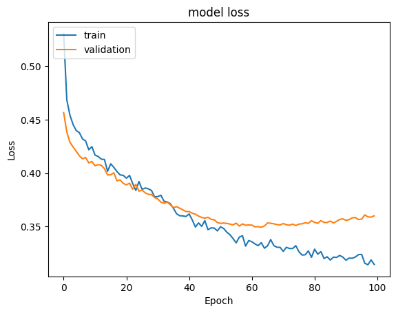

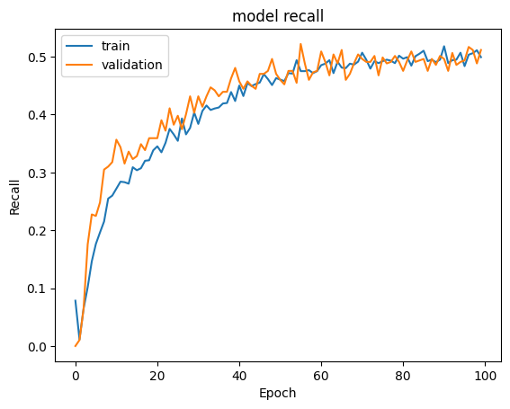

```python
# Plot the graphs
#Plot Train Loss vs Validation Loss
plt.plot(history_2.history['loss'])
plt.plot(history_2.history['val_loss'])
plt.title('model loss')
plt.ylabel('Loss')
plt.xlabel('Epoch')
plt.legend(['train', 'validation'], loc='upper left')
plt.show()

#Plotting Train recall vs Validation recall
plt.plot(history_2.history['recall'])
plt.plot(history_2.history['val_recall'])
plt.title('model recall')
plt.ylabel('Recall')
plt.xlabel('Epoch')
plt.legend(['train', 'validation'], loc='upper left')
plt.show()
```

```python
# Get the performance scores and collate them into the results dataframe

#Call the  utility function to get performance metrics and confusion matrix for the model on its training and val sets
#p_scores will hold all the performance scores ie Acc, Recall, Precision, F1
#cm_score will hold all the confusion matrix scores ie TN, FP, FN, TP
p_scores_model_2_train, cm_scores_model_2_train = Get_model_Performace_metrics_and_confusion_matrix(model_2,X_train,y_train)
p_scores_model_2_val, cm_scores_model_2_val = Get_model_Performace_metrics_and_confusion_matrix(model_2,X_val,y_val)

# Round the values in p_scores_model_0_train,cm_scores_model_0_train,p_scores_model_0_val, cm_scores_model_0_val to 2 decimal places
p_scores_model_2_train = [round(x,2) for x in p_scores_model_2_train]
cm_scores_model_2_train = [round(x,2) for x in cm_scores_model_2_train]
p_scores_model_2_val = [round(x,2) for x in p_scores_model_2_val]
cm_scores_model_2_val = [round(x,2) for x in cm_scores_model_2_val]

# save all the details of model 0 in the results dataframe
results_df.loc[2] = [2,"NN with ADAM and Drop-out",3,"[128,dropout(0.5),64,dropout(0.5),32]",'relu',
                    100,32,history_2.history["loss"][-1],history_2.history["val_loss"][-1],
                    p_scores_model_2_train,p_scores_model_2_val,
                    cm_scores_model_2_train,cm_scores_model_2_val,
                      cm_scores_model_2_train[2]*100/sum(cm_scores_model_2_train),cm_scores_model_2_val[2]*100/sum(cm_scores_model_2_val),
                     round(end-start,2)]
results_df
```

|  | Model No. | Model Name | # of hidden layers | No. of neurons in hidden layers | Activation func | No. of epochs | Batch size | Train loss | Val loss | Train performance score [Acc, Recall, Precision, F1] | Val performance score [Acc, Recall, Precision, F1] | Train confusion matrix [TN, FP, FN, TP] | Val confusion matrix [TN, FP, FN, TP] | FN %-Train set | FN %-Val set | Time Taken (secs) |
| --- | --- | --- | --- | --- | --- | --- | --- | --- | --- | --- | --- | --- | --- | --- | --- | --- |
| 0 | 0 | NN with SGD | 2 | [64, 32] | relu | 100 | 32 | 0.434101 | 0.435346 | [0.8, 0.08, 0.61, 0.13] | [0.8, 0.06, 0.53, 0.12] | [4476, 56, 1074, 88] | [1490, 22, 362, 25] | 18.861960 | 19.062665 | 83.60 |
| 1 | 1 | NN with ADAM | 2 | [64, 32] | relu | 100 | 32 | 0.239275 | 0.411671 | [0.91, 0.7, 0.84, 0.76] | [0.84, 0.55, 0.63, 0.59] | [4374, 158, 352, 810] | [1387, 125, 175, 212] | 6.181946 | 9.215377 | 82.96 |
| 2 | 2 | NN with ADAM and Drop-out | 3 | [128,dropout(0.5),64,dropout(0.5),32] | relu | 100 | 32 | 0.314484 | 0.359958 | [0.88, 0.54, 0.82, 0.65] | [0.85, 0.51, 0.69, 0.59] | [4394, 138, 530, 632] | [1422, 90, 189, 198] | 9.308044 | 9.952607 | 64.71 |

### Neural Network with Balanced Data (by applying SMOTE) and SGD Optimizer

```python
#Using Synthetic Minority Over Sampling Technique
print("Before Oversampling, counts of exited customers in the train-set target: {}".format(sum(y_train == 1)))
print("Before Oversampling, counts of existing customers in the train-set target: {} \n".format(sum(y_train == 0)))

sm = SMOTE( sampling_strategy=1, k_neighbors=5, random_state=42)

X_train_over, y_train_over = sm.fit_resample(X_train, y_train)

print("After Oversampling, counts of exited customers in the train-set target: {}".format(sum(y_train_over == 1)))
print("After Oversampling, counts of existing customers in the train-set target: {} \n".format(sum(y_train_over == 0)))

print("Before Oversampling, the shape of train_X: {}".format(X_train.shape))
print("Before Oversampling, the shape of train_y: {}".format(y_train.shape))

print("\nAfter Oversampling, the shape of train_X: {}".format(X_train_over.shape))
print("After Oversampling, the shape of train_y: {} \n".format(y_train_over.shape))
```

```
Before Oversampling, counts of exited customers in the train-set target: 1162
Before Oversampling, counts of existing customers in the train-set target: 4532

After Oversampling, counts of exited customers in the train-set target: 4532
After Oversampling, counts of existing customers in the train-set target: 4532

Before Oversampling, the shape of train_X: (5694, 11)
Before Oversampling, the shape of train_y: (5694,)

After Oversampling, the shape of train_X: (9064, 11)
After Oversampling, the shape of train_y: (9064,)
```

```python
# Clear the session and fix the random number seed
tf.keras.backend.clear_session()
np.random.seed(42)
random.seed(42)
tf.random.set_seed(42)

# Setup the NN archicature with no drop out
model_3 = Sequential()
model_3.add(Dense(128, activation='relu', input_dim = X_train.shape[1]))  # First hidden layer with 128 neurons and relu activation function
model_3.add(Dense(64, activation='relu'))                     # Second hidden layer with 64 neurons and relu activation function
model_3.add(Dense(32, activation='relu'))                     # Third hidden layer with 32 neurons and relu activation function
model_3.add(Dense(1, activation='sigmoid'))                   # Output layer

# Define the optimization parameters and compile the model
optimizer_sgd = tf.keras.optimizers.SGD(learning_rate=0.0005) # SGD optiizer
metric_R = keras.metrics.Recall()
loss_fuc = 'binary_crossentropy'
model_3.compile(loss = loss_fuc, optimizer = optimizer_sgd, metrics=metric_R)
model_3.summary()
```

```
Model: "sequential"
_________________________________________________________________
 Layer (type)                Output Shape              Param #
=================================================================
 dense (Dense)               (None, 128)               1536

 dense_1 (Dense)             (None, 64)                8256

 dense_2 (Dense)             (None, 32)                2080

 dense_3 (Dense)             (None, 1)                 33

=================================================================
Total params: 11905 (46.50 KB)
Trainable params: 11905 (46.50 KB)
Non-trainable params: 0 (0.00 Byte)
_________________________________________________________________
```

```python
#Fit the neural network on the train and validation sets
#retain the same batch size and epochs as earlier
batch_size = 32
epochs = 100

start = time.time()
history_3 = model_3.fit(X_train_over, y_train_over, validation_data=(X_val,y_val) , batch_size=batch_size, epochs=epochs, verbose=2)
end = time.time()
```

```
284/284 - 3s - loss: 0.7044 - recall: 0.9058 - val_loss: 0.7397 - val_recall: 0.8760 - 3s/epoch - 9ms/step
284/284 - 1s - loss: 0.7000 - recall: 0.8855 - val_loss: 0.7291 - val_recall: 0.8579 - 853ms/epoch - 3ms/step
284/284 - 1s - loss: 0.6961 - recall: 0.8663 - val_loss: 0.7194 - val_recall: 0.8372 - 643ms/epoch - 2ms/step
284/284 - 1s - loss: 0.6924 - recall: 0.8305 - val_loss: 0.7105 - val_recall: 0.8062 - 652ms/epoch - 2ms/step
284/284 - 1s - loss: 0.6889 - recall: 0.7926 - val_loss: 0.7023 - val_recall: 0.7623 - 570ms/epoch - 2ms/step
284/284 - 1s - loss: 0.6856 - recall: 0.7540 - val_loss: 0.6947 - val_recall: 0.7235 - 650ms/epoch - 2ms/step
284/284 - 1s - loss: 0.6823 - recall: 0.7156 - val_loss: 0.6872 - val_recall: 0.6925 - 635ms/epoch - 2ms/step
284/284 - 1s - loss: 0.6790 - recall: 0.6798 - val_loss: 0.6800 - val_recall: 0.6693 - 666ms/epoch - 2ms/step
284/284 - 1s - loss: 0.6759 - recall: 0.6509 - val_loss: 0.6733 - val_recall: 0.6537 - 696ms/epoch - 2ms/step
284/284 - 1s - loss: 0.6728 - recall: 0.6381 - val_loss: 0.6667 - val_recall: 0.6202 - 676ms/epoch - 2ms/step
284/284 - 1s - loss: 0.6697 - recall: 0.6211 - val_loss: 0.6605 - val_recall: 0.6124 - 625ms/epoch - 2ms/step
284/284 - 1s - loss: 0.6666 - recall: 0.6061 - val_loss: 0.6547 - val_recall: 0.5891 - 621ms/epoch - 2ms/step
284/284 - 1s - loss: 0.6636 - recall: 0.5951 - val_loss: 0.6491 - val_recall: 0.5762 - 623ms/epoch - 2ms/step
284/284 - 1s - loss: 0.6606 - recall: 0.5861 - val_loss: 0.6439 - val_recall: 0.5685 - 759ms/epoch - 3ms/step
284/284 - 1s - loss: 0.6575 - recall: 0.5850 - val_loss: 0.6388 - val_recall: 0.5736 - 680ms/epoch - 2ms/step
284/284 - 1s - loss: 0.6545 - recall: 0.5838 - val_loss: 0.6343 - val_recall: 0.5685 - 630ms/epoch - 2ms/step
284/284 - 1s - loss: 0.6514 - recall: 0.5911 - val_loss: 0.6299 - val_recall: 0.5685 - 860ms/epoch - 3ms/step
284/284 - 1s - loss: 0.6483 - recall: 0.5907 - val_loss: 0.6262 - val_recall: 0.5711 - 1s/epoch - 4ms/step
284/284 - 1s - loss: 0.6453 - recall: 0.6000 - val_loss: 0.6226 - val_recall: 0.5736 - 1s/epoch - 4ms/step
284/284 - 1s - loss: 0.6422 - recall: 0.6068 - val_loss: 0.6192 - val_recall: 0.5814 - 1s/epoch - 4ms/step
284/284 - 1s - loss: 0.6391 - recall: 0.6136 - val_loss: 0.6158 - val_recall: 0.5866 - 739ms/epoch - 3ms/step
284/284 - 1s - loss: 0.6359 - recall: 0.6180 - val_loss: 0.6127 - val_recall: 0.5891 - 580ms/epoch - 2ms/step
284/284 - 1s - loss: 0.6328 - recall: 0.6256 - val_loss: 0.6099 - val_recall: 0.5943 - 600ms/epoch - 2ms/step
284/284 - 1s - loss: 0.6296 - recall: 0.6306 - val_loss: 0.6074 - val_recall: 0.5969 - 635ms/epoch - 2ms/step
284/284 - 1s - loss: 0.6265 - recall: 0.6386 - val_loss: 0.6045 - val_recall: 0.6021 - 611ms/epoch - 2ms/step
284/284 - 1s - loss: 0.6233 - recall: 0.6401 - val_loss: 0.6021 - val_recall: 0.6021 - 694ms/epoch - 2ms/step
284/284 - 1s - loss: 0.6202 - recall: 0.6465 - val_loss: 0.5997 - val_recall: 0.6124 - 611ms/epoch - 2ms/step
284/284 - 1s - loss: 0.6170 - recall: 0.6529 - val_loss: 0.5972 - val_recall: 0.6150 - 607ms/epoch - 2ms/step
284/284 - 1s - loss: 0.6139 - recall: 0.6580 - val_loss: 0.5948 - val_recall: 0.6253 - 623ms/epoch - 2ms/step
284/284 - 1s - loss: 0.6108 - recall: 0.6571 - val_loss: 0.5931 - val_recall: 0.6305 - 573ms/epoch - 2ms/step
284/284 - 1s - loss: 0.6077 - recall: 0.6637 - val_loss: 0.5912 - val_recall: 0.6357 - 628ms/epoch - 2ms/step
284/284 - 1s - loss: 0.6047 - recall: 0.6712 - val_loss: 0.5890 - val_recall: 0.6331 - 677ms/epoch - 2ms/step
284/284 - 1s - loss: 0.6017 - recall: 0.6732 - val_loss: 0.5874 - val_recall: 0.6408 - 710ms/epoch - 2ms/step
284/284 - 1s - loss: 0.5988 - recall: 0.6783 - val_loss: 0.5853 - val_recall: 0.6460 - 628ms/epoch - 2ms/step
284/284 - 1s - loss: 0.5959 - recall: 0.6838 - val_loss: 0.5833 - val_recall: 0.6486 - 678ms/epoch - 2ms/step
284/284 - 1s - loss: 0.5931 - recall: 0.6882 - val_loss: 0.5813 - val_recall: 0.6563 - 668ms/epoch - 2ms/step
284/284 - 1s - loss: 0.5903 - recall: 0.6900 - val_loss: 0.5803 - val_recall: 0.6589 - 979ms/epoch - 3ms/step
284/284 - 1s - loss: 0.5877 - recall: 0.6970 - val_loss: 0.5783 - val_recall: 0.6615 - 920ms/epoch - 3ms/step
284/284 - 1s - loss: 0.5851 - recall: 0.6999 - val_loss: 0.5770 - val_recall: 0.6615 - 1s/epoch - 4ms/step
284/284 - 1s - loss: 0.5826 - recall: 0.7048 - val_loss: 0.5750 - val_recall: 0.6589 - 1s/epoch - 4ms/step
```

[output cut: 45 more lines]

```
284/284 - 1s - loss: 0.5292 - recall: 0.7566 - val_loss: 0.5450 - val_recall: 0.6925 - 652ms/epoch - 2ms/step
284/284 - 1s - loss: 0.5287 - recall: 0.7538 - val_loss: 0.5455 - val_recall: 0.6977 - 696ms/epoch - 2ms/step
284/284 - 1s - loss: 0.5281 - recall: 0.7544 - val_loss: 0.5449 - val_recall: 0.7003 - 658ms/epoch - 2ms/step
284/284 - 1s - loss: 0.5276 - recall: 0.7544 - val_loss: 0.5451 - val_recall: 0.7003 - 616ms/epoch - 2ms/step
284/284 - 1s - loss: 0.5271 - recall: 0.7546 - val_loss: 0.5460 - val_recall: 0.7003 - 611ms/epoch - 2ms/step
284/284 - 1s - loss: 0.5265 - recall: 0.7566 - val_loss: 0.5456 - val_recall: 0.6925 - 568ms/epoch - 2ms/step
284/284 - 1s - loss: 0.5260 - recall: 0.7564 - val_loss: 0.5449 - val_recall: 0.6925 - 910ms/epoch - 3ms/step
284/284 - 1s - loss: 0.5255 - recall: 0.7575 - val_loss: 0.5440 - val_recall: 0.6899 - 940ms/epoch - 3ms/step
284/284 - 1s - loss: 0.5250 - recall: 0.7551 - val_loss: 0.5453 - val_recall: 0.6977 - 1s/epoch - 4ms/step
284/284 - 1s - loss: 0.5245 - recall: 0.7571 - val_loss: 0.5450 - val_recall: 0.6977 - 1s/epoch - 4ms/step
284/284 - 1s - loss: 0.5241 - recall: 0.7571 - val_loss: 0.5437 - val_recall: 0.6951 - 729ms/epoch - 3ms/step
284/284 - 1s - loss: 0.5236 - recall: 0.7560 - val_loss: 0.5453 - val_recall: 0.6977 - 688ms/epoch - 2ms/step
284/284 - 1s - loss: 0.5231 - recall: 0.7573 - val_loss: 0.5447 - val_recall: 0.6951 - 657ms/epoch - 2ms/step
284/284 - 1s - loss: 0.5226 - recall: 0.7584 - val_loss: 0.5420 - val_recall: 0.6951 - 669ms/epoch - 2ms/step
284/284 - 1s - loss: 0.5222 - recall: 0.7562 - val_loss: 0.5433 - val_recall: 0.6951 - 643ms/epoch - 2ms/step
```

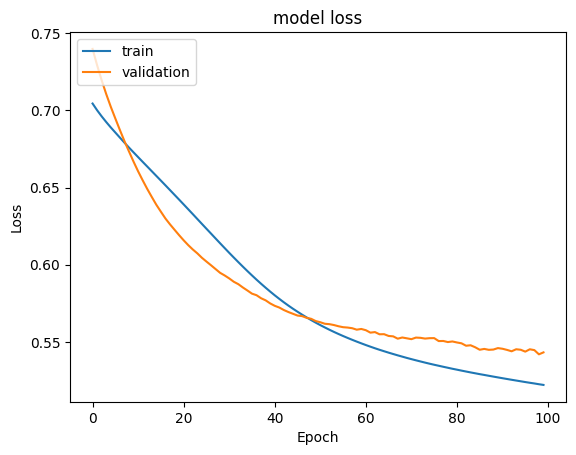

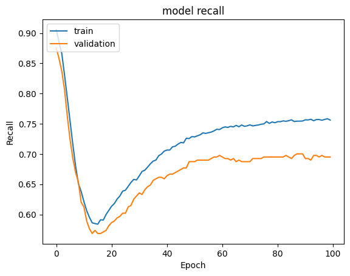

```python
# Plot the graphs
#Plot Train Loss vs Validation Loss
plt.plot(history_3.history['loss'])
plt.plot(history_3.history['val_loss'])
plt.title('model loss')
plt.ylabel('Loss')
plt.xlabel('Epoch')
plt.legend(['train', 'validation'], loc='upper left')
plt.show()

#Plotting Train recall vs Validation recall
plt.plot(history_3.history['recall'])
plt.plot(history_3.history['val_recall'])
plt.title('model recall')
plt.ylabel('Recall')
plt.xlabel('Epoch')
plt.legend(['train', 'validation'], loc='upper left')
plt.show()
```

```python
# Get the performance scores and collate them into the results dataframe

#Call the  utility function to get performance metrics and confusion matrix , round them and save them in the results df
p_scores_model_3_train, cm_scores_model_3_train = Get_model_Performace_metrics_and_confusion_matrix(model_3,X_train_over,y_train_over)
p_scores_model_3_val, cm_scores_model_3_val = Get_model_Performace_metrics_and_confusion_matrix(model_3,X_val,y_val)

p_scores_model_3_train = [round(x,2) for x in p_scores_model_3_train]
cm_scores_model_3_train = [round(x,2) for x in cm_scores_model_3_train]
p_scores_model_3_val = [round(x,2) for x in p_scores_model_3_val]
cm_scores_model_3_val = [round(x,2) for x in cm_scores_model_3_val]

results_df.loc[3] = [3,"NN with SMOTE data and SGD",3,"[128,64,32]",'relu',
                    100,32,history_3.history["loss"][-1],history_3.history["val_loss"][-1],
                    p_scores_model_3_train,p_scores_model_3_val,
                    cm_scores_model_3_train,cm_scores_model_3_val,
                      cm_scores_model_3_train[2]*100/sum(cm_scores_model_3_train),cm_scores_model_3_val[2]*100/sum(cm_scores_model_3_val),
                     round(end-start,2)]
results_df
```

|  | Model No. | Model Name | # of hidden layers | No. of neurons in hidden layers | Activation func | No. of epochs | Batch size | Train loss | Val loss | Train performance score [Acc, Recall, Precision, F1] | Val performance score [Acc, Recall, Precision, F1] | Train confusion matrix [TN, FP, FN, TP] | Val confusion matrix [TN, FP, FN, TP] | FN %-Train set | FN %-Val set | Time Taken (secs) |
| --- | --- | --- | --- | --- | --- | --- | --- | --- | --- | --- | --- | --- | --- | --- | --- | --- |
| 0 | 0 | NN with SGD | 2 | [64, 32] | relu | 100 | 32 | 0.434101 | 0.435346 | [0.8, 0.08, 0.61, 0.13] | [0.8, 0.06, 0.53, 0.12] | [4476, 56, 1074, 88] | [1490, 22, 362, 25] | 18.861960 | 19.062665 | 83.60 |
| 1 | 1 | NN with ADAM | 2 | [64, 32] | relu | 100 | 32 | 0.239275 | 0.411671 | [0.91, 0.7, 0.84, 0.76] | [0.84, 0.55, 0.63, 0.59] | [4374, 158, 352, 810] | [1387, 125, 175, 212] | 6.181946 | 9.215377 | 82.96 |
| 2 | 2 | NN with ADAM and Drop-out | 3 | [128,dropout(0.5),64,dropout(0.5),32] | relu | 100 | 32 | 0.314484 | 0.359958 | [0.88, 0.54, 0.82, 0.65] | [0.85, 0.51, 0.69, 0.59] | [4394, 138, 530, 632] | [1422, 90, 189, 198] | 9.308044 | 9.952607 | 64.71 |
| 3 | 3 | NN with SMOTE data and SGD | 3 | [128,64,32] | relu | 100 | 32 | 0.522195 | 0.543268 | [0.75, 0.76, 0.75, 0.75] | [0.72, 0.7, 0.4, 0.51] | [3358, 1174, 1099, 3433] | [1104, 408, 118, 269] | 12.124890 | 6.213797 | 83.08 |

### Neural Network with Balanced Data (by applying SMOTE) and Adam Optimizer

```python
# Clear the session and fix the random number seed
tf.keras.backend.clear_session()
np.random.seed(42)
random.seed(42)
tf.random.set_seed(42)

# Setup the NN archicature with no drop out
model_4 = Sequential()
model_4.add(Dense(128, activation='relu', input_dim = X_train.shape[1]))  # First hidden layer with 128 neurons and relu activation function
model_4.add(Dense(64, activation='relu'))                     # Second hidden layer with 64 neurons and relu activation function
model_4.add(Dense(32, activation='relu'))                     # Third hidden layer with 32 neurons and relu activation function
model_4.add(Dense(1, activation='sigmoid'))                   # Output layer

# Define the optimization parameters and compile the model
optimizer_adam = tf.keras.optimizers.Adam(learning_rate=0.0005) # SGD optiizer
metric_R = keras.metrics.Recall()
loss_fuc = 'binary_crossentropy'
model_4.compile(loss = loss_fuc, optimizer = optimizer_adam, metrics=metric_R)
model_4.summary()
```

```
Model: "sequential"
_________________________________________________________________
 Layer (type)                Output Shape              Param #
=================================================================
 dense (Dense)               (None, 128)               1536

 dense_1 (Dense)             (None, 64)                8256

 dense_2 (Dense)             (None, 32)                2080

 dense_3 (Dense)             (None, 1)                 33

=================================================================
Total params: 11905 (46.50 KB)
Trainable params: 11905 (46.50 KB)
Non-trainable params: 0 (0.00 Byte)
_________________________________________________________________
```

```python
#Fit the neural network on the train and validation sets
#retain the same batch size and epochs as earlier
batch_size = 32
epochs = 100

start = time.time()
history_4 = model_4.fit(X_train_over, y_train_over, validation_data=(X_val,y_val) , batch_size=batch_size, epochs=epochs, verbose=2)
end = time.time()
```

```
284/284 - 2s - loss: 0.5595 - recall: 0.7255 - val_loss: 0.5520 - val_recall: 0.6951 - 2s/epoch - 7ms/step
284/284 - 1s - loss: 0.4862 - recall: 0.7604 - val_loss: 0.5529 - val_recall: 0.7313 - 664ms/epoch - 2ms/step
284/284 - 1s - loss: 0.4476 - recall: 0.7835 - val_loss: 0.4800 - val_recall: 0.6589 - 724ms/epoch - 3ms/step
284/284 - 1s - loss: 0.4189 - recall: 0.8012 - val_loss: 0.4705 - val_recall: 0.6253 - 632ms/epoch - 2ms/step
284/284 - 1s - loss: 0.4017 - recall: 0.8171 - val_loss: 0.4740 - val_recall: 0.6693 - 714ms/epoch - 3ms/step
284/284 - 1s - loss: 0.3845 - recall: 0.8261 - val_loss: 0.4726 - val_recall: 0.6770 - 713ms/epoch - 3ms/step
284/284 - 1s - loss: 0.3692 - recall: 0.8341 - val_loss: 0.4775 - val_recall: 0.6563 - 664ms/epoch - 2ms/step
284/284 - 1s - loss: 0.3618 - recall: 0.8455 - val_loss: 0.4771 - val_recall: 0.6563 - 656ms/epoch - 2ms/step
284/284 - 1s - loss: 0.3505 - recall: 0.8519 - val_loss: 0.4746 - val_recall: 0.6176 - 636ms/epoch - 2ms/step
284/284 - 1s - loss: 0.3428 - recall: 0.8561 - val_loss: 0.4544 - val_recall: 0.5762 - 700ms/epoch - 2ms/step
284/284 - 1s - loss: 0.3369 - recall: 0.8533 - val_loss: 0.4976 - val_recall: 0.6744 - 730ms/epoch - 3ms/step
284/284 - 1s - loss: 0.3258 - recall: 0.8583 - val_loss: 0.4833 - val_recall: 0.6537 - 1s/epoch - 4ms/step
284/284 - 1s - loss: 0.3204 - recall: 0.8639 - val_loss: 0.4606 - val_recall: 0.5711 - 1s/epoch - 4ms/step
284/284 - 1s - loss: 0.3132 - recall: 0.8698 - val_loss: 0.4647 - val_recall: 0.6021 - 1s/epoch - 4ms/step
284/284 - 1s - loss: 0.3121 - recall: 0.8742 - val_loss: 0.5060 - val_recall: 0.6512 - 1s/epoch - 4ms/step
284/284 - 1s - loss: 0.3029 - recall: 0.8775 - val_loss: 0.5385 - val_recall: 0.6718 - 705ms/epoch - 2ms/step
284/284 - 1s - loss: 0.2960 - recall: 0.8839 - val_loss: 0.4871 - val_recall: 0.5891 - 701ms/epoch - 2ms/step
284/284 - 1s - loss: 0.2913 - recall: 0.8861 - val_loss: 0.5037 - val_recall: 0.6331 - 707ms/epoch - 2ms/step
284/284 - 1s - loss: 0.2850 - recall: 0.8848 - val_loss: 0.5258 - val_recall: 0.6693 - 692ms/epoch - 2ms/step
284/284 - 1s - loss: 0.2810 - recall: 0.8912 - val_loss: 0.5049 - val_recall: 0.6072 - 702ms/epoch - 2ms/step
284/284 - 1s - loss: 0.2761 - recall: 0.8906 - val_loss: 0.5345 - val_recall: 0.6434 - 657ms/epoch - 2ms/step
284/284 - 1s - loss: 0.2668 - recall: 0.8952 - val_loss: 0.6027 - val_recall: 0.6770 - 671ms/epoch - 2ms/step
284/284 - 1s - loss: 0.2642 - recall: 0.9007 - val_loss: 0.5278 - val_recall: 0.6253 - 621ms/epoch - 2ms/step
284/284 - 1s - loss: 0.2601 - recall: 0.9034 - val_loss: 0.5391 - val_recall: 0.6176 - 739ms/epoch - 3ms/step
284/284 - 1s - loss: 0.2583 - recall: 0.9047 - val_loss: 0.5361 - val_recall: 0.6021 - 629ms/epoch - 2ms/step
284/284 - 1s - loss: 0.2518 - recall: 0.9071 - val_loss: 0.5584 - val_recall: 0.6124 - 709ms/epoch - 2ms/step
284/284 - 1s - loss: 0.2456 - recall: 0.9093 - val_loss: 0.5884 - val_recall: 0.6693 - 700ms/epoch - 2ms/step
284/284 - 1s - loss: 0.2431 - recall: 0.9115 - val_loss: 0.6189 - val_recall: 0.6770 - 704ms/epoch - 2ms/step
284/284 - 1s - loss: 0.2382 - recall: 0.9148 - val_loss: 0.5376 - val_recall: 0.5969 - 739ms/epoch - 3ms/step
284/284 - 1s - loss: 0.2326 - recall: 0.9195 - val_loss: 0.5779 - val_recall: 0.6331 - 971ms/epoch - 3ms/step
284/284 - 1s - loss: 0.2321 - recall: 0.9177 - val_loss: 0.5594 - val_recall: 0.6021 - 1s/epoch - 4ms/step
284/284 - 1s - loss: 0.2252 - recall: 0.9241 - val_loss: 0.5750 - val_recall: 0.5917 - 1s/epoch - 4ms/step
284/284 - 1s - loss: 0.2181 - recall: 0.9241 - val_loss: 0.5961 - val_recall: 0.5891 - 864ms/epoch - 3ms/step
284/284 - 1s - loss: 0.2201 - recall: 0.9243 - val_loss: 0.6075 - val_recall: 0.6021 - 649ms/epoch - 2ms/step
284/284 - 1s - loss: 0.2145 - recall: 0.9259 - val_loss: 0.6036 - val_recall: 0.6227 - 624ms/epoch - 2ms/step
284/284 - 1s - loss: 0.2076 - recall: 0.9296 - val_loss: 0.5820 - val_recall: 0.5426 - 723ms/epoch - 3ms/step
284/284 - 1s - loss: 0.2108 - recall: 0.9303 - val_loss: 0.5983 - val_recall: 0.5840 - 655ms/epoch - 2ms/step
284/284 - 1s - loss: 0.2048 - recall: 0.9329 - val_loss: 0.6648 - val_recall: 0.6408 - 662ms/epoch - 2ms/step
284/284 - 1s - loss: 0.1998 - recall: 0.9373 - val_loss: 0.6119 - val_recall: 0.5762 - 770ms/epoch - 3ms/step
284/284 - 1s - loss: 0.1977 - recall: 0.9316 - val_loss: 0.6462 - val_recall: 0.6305 - 703ms/epoch - 2ms/step
```

[output cut: 45 more lines]

```
284/284 - 1s - loss: 0.1041 - recall: 0.9647 - val_loss: 0.9326 - val_recall: 0.5659 - 726ms/epoch - 3ms/step
284/284 - 1s - loss: 0.1023 - recall: 0.9665 - val_loss: 1.0038 - val_recall: 0.6098 - 623ms/epoch - 2ms/step
284/284 - 1s - loss: 0.0941 - recall: 0.9673 - val_loss: 0.9678 - val_recall: 0.5556 - 770ms/epoch - 3ms/step
284/284 - 1s - loss: 0.0895 - recall: 0.9733 - val_loss: 1.0508 - val_recall: 0.5607 - 681ms/epoch - 2ms/step
284/284 - 1s - loss: 0.0897 - recall: 0.9689 - val_loss: 0.9827 - val_recall: 0.5633 - 707ms/epoch - 2ms/step
284/284 - 1s - loss: 0.1025 - recall: 0.9616 - val_loss: 0.9810 - val_recall: 0.5814 - 628ms/epoch - 2ms/step
284/284 - 1s - loss: 0.0902 - recall: 0.9715 - val_loss: 0.9985 - val_recall: 0.5220 - 639ms/epoch - 2ms/step
284/284 - 1s - loss: 0.0948 - recall: 0.9678 - val_loss: 0.9909 - val_recall: 0.5556 - 640ms/epoch - 2ms/step
284/284 - 1s - loss: 0.0874 - recall: 0.9746 - val_loss: 1.0317 - val_recall: 0.5788 - 699ms/epoch - 2ms/step
284/284 - 1s - loss: 0.0850 - recall: 0.9757 - val_loss: 1.0233 - val_recall: 0.5659 - 727ms/epoch - 3ms/step
284/284 - 1s - loss: 0.0852 - recall: 0.9718 - val_loss: 1.0478 - val_recall: 0.5736 - 649ms/epoch - 2ms/step
284/284 - 1s - loss: 0.0873 - recall: 0.9707 - val_loss: 1.0238 - val_recall: 0.4961 - 709ms/epoch - 2ms/step
284/284 - 1s - loss: 0.0868 - recall: 0.9722 - val_loss: 1.0668 - val_recall: 0.4910 - 726ms/epoch - 3ms/step
284/284 - 1s - loss: 0.0915 - recall: 0.9673 - val_loss: 1.1506 - val_recall: 0.5762 - 652ms/epoch - 2ms/step
284/284 - 1s - loss: 0.0834 - recall: 0.9742 - val_loss: 1.1188 - val_recall: 0.5891 - 1s/epoch - 4ms/step
```

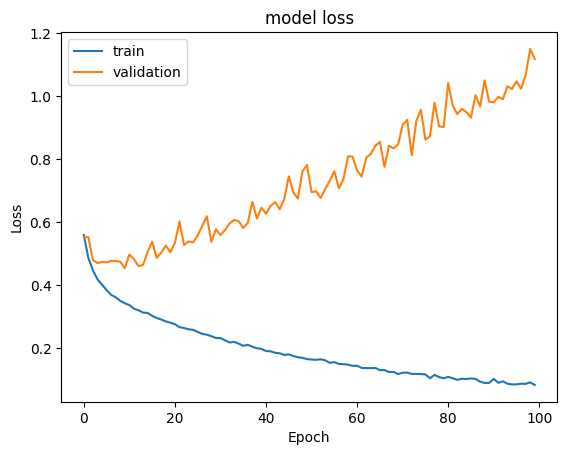

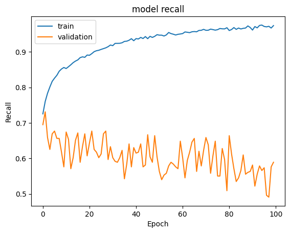

```python
# Plot the graphs
#Plot Train Loss vs Validation Loss
plt.plot(history_4.history['loss'])
plt.plot(history_4.history['val_loss'])
plt.title('model loss')
plt.ylabel('Loss')
plt.xlabel('Epoch')
plt.legend(['train', 'validation'], loc='upper left')
plt.show()

#Plotting Train recall vs Validation recall
plt.plot(history_4.history['recall'])
plt.plot(history_4.history['val_recall'])
plt.title('model recall')
plt.ylabel('Recall')
plt.xlabel('Epoch')
plt.legend(['train', 'validation'], loc='upper left')
plt.show()
```

```python
# Get the performance scores and collate them into the results dataframe

#Call the  utility function to get performance metrics and confusion matrix , round them and save them in the results df
p_scores_model_4_train, cm_scores_model_4_train = Get_model_Performace_metrics_and_confusion_matrix(model_4,X_train_over,y_train_over)
p_scores_model_4_val, cm_scores_model_4_val = Get_model_Performace_metrics_and_confusion_matrix(model_4,X_val,y_val)

p_scores_model_4_train = [round(x,2) for x in p_scores_model_4_train]
cm_scores_model_4_train = [round(x,2) for x in cm_scores_model_4_train]
p_scores_model_4_val = [round(x,2) for x in p_scores_model_4_val]
cm_scores_model_4_val = [round(x,2) for x in cm_scores_model_4_val]

results_df.loc[4] = [4,"NN with SMOTE data and ADAM",3,"[128,64,32]",'relu',
                    100,32,history_4.history["loss"][-1],history_4.history["val_loss"][-1],
                    p_scores_model_4_train,p_scores_model_4_val,
                    cm_scores_model_4_train,cm_scores_model_4_val,
                      cm_scores_model_4_train[2]*100/sum(cm_scores_model_4_train),cm_scores_model_4_val[2]*100/sum(cm_scores_model_4_val),
                     round(end-start,2)]
results_df
```

|  | Model No. | Model Name | # of hidden layers | No. of neurons in hidden layers | Activation func | No. of epochs | Batch size | Train loss | Val loss | Train performance score [Acc, Recall, Precision, F1] | Val performance score [Acc, Recall, Precision, F1] | Train confusion matrix [TN, FP, FN, TP] | Val confusion matrix [TN, FP, FN, TP] | FN %-Train set | FN %-Val set | Time Taken (secs) |
| --- | --- | --- | --- | --- | --- | --- | --- | --- | --- | --- | --- | --- | --- | --- | --- | --- |
| 0 | 0 | NN with SGD | 2 | [64, 32] | relu | 100 | 32 | 0.434101 | 0.435346 | [0.8, 0.08, 0.61, 0.13] | [0.8, 0.06, 0.53, 0.12] | [4476, 56, 1074, 88] | [1490, 22, 362, 25] | 18.861960 | 19.062665 | 83.60 |
| 1 | 1 | NN with ADAM | 2 | [64, 32] | relu | 100 | 32 | 0.239275 | 0.411671 | [0.91, 0.7, 0.84, 0.76] | [0.84, 0.55, 0.63, 0.59] | [4374, 158, 352, 810] | [1387, 125, 175, 212] | 6.181946 | 9.215377 | 82.96 |
| 2 | 2 | NN with ADAM and Drop-out | 3 | [128,dropout(0.5),64,dropout(0.5),32] | relu | 100 | 32 | 0.314484 | 0.359958 | [0.88, 0.54, 0.82, 0.65] | [0.85, 0.51, 0.69, 0.59] | [4394, 138, 530, 632] | [1422, 90, 189, 198] | 9.308044 | 9.952607 | 64.71 |
| 3 | 3 | NN with SMOTE data and SGD | 3 | [128,64,32] | relu | 100 | 32 | 0.522195 | 0.543268 | [0.75, 0.76, 0.75, 0.75] | [0.72, 0.7, 0.4, 0.51] | [3358, 1174, 1099, 3433] | [1104, 408, 118, 269] | 12.124890 | 6.213797 | 83.08 |
| 4 | 4 | NN with SMOTE data and ADAM | 3 | [128,64,32] | relu | 100 | 32 | 0.083418 | 1.118810 | [0.98, 0.99, 0.96, 0.98] | [0.77, 0.59, 0.45, 0.51] | [4334, 198, 28, 4504] | [1237, 275, 159, 228] | 0.308914 | 8.372828 | 78.62 |

Observations:

- We see here that the model 4 has clearly overfit with the training set. Therfore in addition to regularization technique such as Dropout and data augmentation ( ie through SMOTE), we will also employ Batch Normalization technique in the following section.
- We will also use tanh activation function as apposed to relu since model 4 was lower than recall of model 3 insite of a better optiization technique ie ADAM vs SGD